# MPA 5830 - Module 05 Exercises

Ani Ruhil

2018-08-04

# Practice Tasks

## (1)

Create a map of the 48 contiguous states in the United State. Be sure to title the map and to fill in each state with colors while drawing state borders in white. Make sure you add state names by first calculating the centroids of each state and then merging these latitudes and longitudes with the map data. Use `theme_map()` and make sure the legend is not visible.

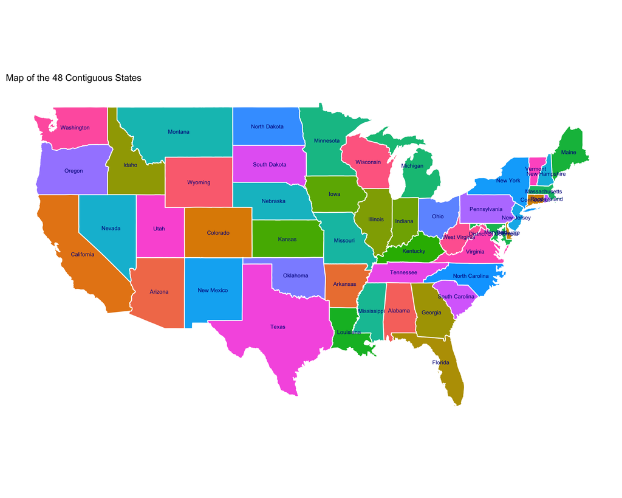

```r
library(ggplot2)
library(ggmap)
library(maps)
library(mapdata)
library(maptools)
library(ggthemes)

usast <- map_data("state")

library(stringr)
usast$statename <- str_to_title(usast$region)

library(sp)
getLabelPoint <- function(statename) {
    Polygon(statename[c("long", "lat")])@labpt
}
centroids = by(usast, usast$statename, getLabelPoint)
centroids2 <- do.call("rbind.data.frame",
    centroids)
centroids2$statename = rownames(centroids)
names(centroids2) <- c("clong", "clat", "statename")

ggplot() + geom_polygon(data = usast, aes(x = long,
    y = lat, group = group, fill = statename),
    color = "white") + geom_text(data = centroids2,
    aes(x = clong, y = clat, label = statename),
    color = "darkblue", size = 2.25) + coord_fixed(1.3) +
    labs(title = "Map of the 48 Contiguous States") +
    theme_map() + theme(legend.position = "none")
```

## (2)

Run the following code chunk to load data on the murder, assault and rape rates per 100,000 persons. Urbanpop is the percent of the state population that lives in an urban area.

```r
data("USArrests")
names(USArrests)
```

```
## [1] "Murder"   "Assault"  "UrbanPop" "Rape"
```

```r
USArrests$statename <- rownames(USArrests)

library(ggplot2)
library(ggmap)
library(maps)
library(mapdata)
library(maptools)
library(ggthemes)

usast <- map_data("state")

library(stringr)
usast$statename <- str_to_title(usast$region)

library(dplyr)
usast2 <- usast %>% filter(statename != "District Of Columbia")
```

Now use murder rates to create `quintiles` that represent groups of murder rates. This grouped murder rate should then be used to create a map of the 48 states you drew in (1) except with the states colored on the basis of grouped murder rates. The legend should be at the bottom.

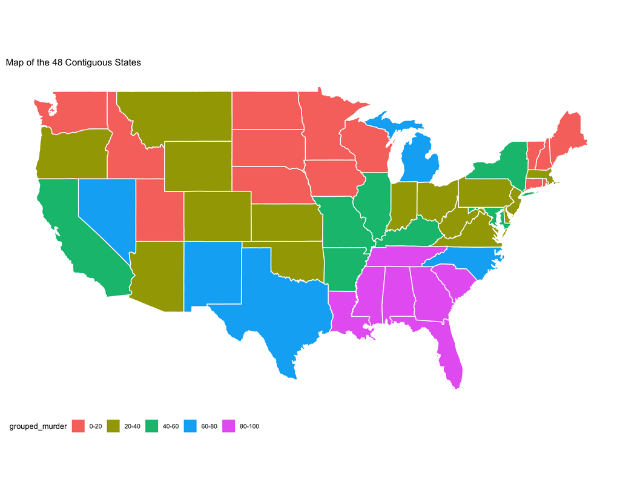

```r
library(dplyr)
my.df = merge(usast2, USArrests, by = "statename",
    all.x = TRUE, sort = FALSE)
my.df = my.df[order(my.df$order), ]
my.df <- my.df %>% mutate(grouped_murder = cut(Murder,
    breaks = c(quantile(my.df$Murder, probs = seq(0,
        1, by = 0.2))), labels = c("0-20",
        "20-40", "40-60", "60-80", "80-100"),
    include.lowest = TRUE))

ggplot() + geom_polygon(data = my.df, aes(x = long,
    y = lat, group = group, fill = grouped_murder),
    color = "white") + coord_fixed(1.3) +
    labs(title = "Map of the 48 Contiguous States") +
    theme_map() + theme(legend.position = "bottom")
```

## (3)

Use the original USArrests data to draw scatterplots of (a) Murder versus UrbanPop, (b) Assault versus UrbanPop, and (c) Rape versus UrbanPop. Save each of these scatterplots by name and then use `patchwork` to create a single canvas that includes all three plots. Make sure you label the x-axis, y-axis, and title each plot.

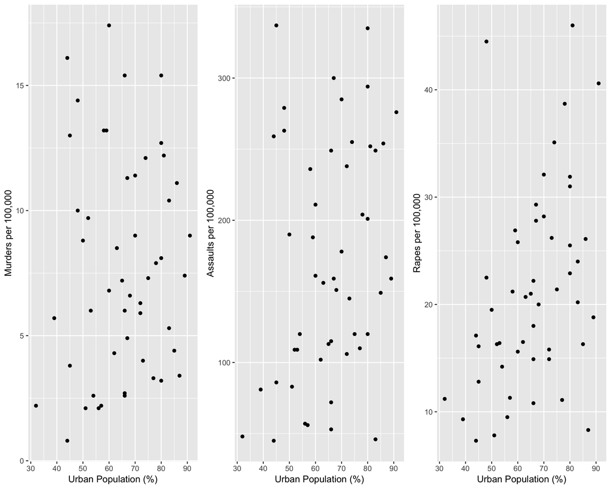

```r
p1 <- ggplot(data = USArrests, aes(x = UrbanPop,
    y = Murder)) + geom_point() + labs(x = "Urban Population (%)",
    y = "Murders per 100,000")
p2 <- ggplot(data = USArrests, aes(x = UrbanPop,
    y = Assault)) + geom_point() + labs(x = "Urban Population (%)",
    y = "Assaults per 100,000")
p3 <- ggplot(data = USArrests, aes(x = UrbanPop,
    y = Rape)) + geom_point() + labs(x = "Urban Population (%)",
    y = "Rapes per 100,000")

library(patchwork)
p1 + p2 + p3
```

## (4)

Now create `highcharter` versions of each of the three scatterplots you created in (3) above. You should end up with three scatterplots, each on its own canvas.

```r
library(highcharter)
hchart(USArrests, "scatter", hcaes(x = UrbanPop,
    y = Murder))
```

[interactive chart not shown]

```r
hchart(USArrests, "scatter", hcaes(x = UrbanPop,
    y = Assault))
```

[interactive chart not shown]

```r
hchart(USArrests, "scatter", hcaes(x = UrbanPop,
    y = Rape))
```

[interactive chart not shown]

## (5)

Use `leaflet` to create a map that includes a popup for your place of birth. You will need to use Google maps to find the latitude/longitude for this place. The popup should display the name of this place.

```r
library(leaflet)
library(leaflet.extras)
library(widgetframe)

l11 <- leaflet() %>% setView(lat = 19.898481,
    lng = 73.827411, zoom = 11) %>% addMarkers(lat = 19.898481,
    lng = 73.827411, popup = c("The Military Hospital, Deolali, India")) %>%
    addTiles() %>% setMapWidgetStyle() %>%
    frameWidget(width = "700", height = "500")
l11
```

[interactive chart not shown]